# Dow Jones Industrial

```r
install.packages('quantmod')
install.packages('tseries')
install.packages('forecast')
install.packages('car')
install.packages('FinTS')
install.packages('rugarch')
install.packages('utf8')
install.packages('ggplot2')
library(quantmod)
library(tseries)
library(car)
library(FinTS)
library(utf8)
library(ggplot2)
library(forecast)
library(rugarch)
lapply(packages, require, character.only = TRUE)
```

```r
packages = c('quantmod','car','forecast','tseries','FinTS', 'rugarch','utf8','ggplot2')
install.packages(packages, dependencies = TRUE)
```

```
Error in install.packages : Updating loaded packages
```

```r
lapply(packages, require, character.only=TRUE)
```

```
[[1]]
[1] TRUE

[[2]]
[1] TRUE

[[3]]
[1] TRUE

[[4]]
[1] TRUE

[[5]]
[1] TRUE

[[6]]
[1] TRUE

[[7]]
[1] TRUE

[[8]]
[1] TRUE
```

**Downloading the stock data**

```r
getSymbols(Symbols = '^DJI',
           src = 'yahoo',
           from = as.Date('2016-01-01'),
           to = as.Date('2023-12-31'),
           periodicity = 'daily')
```

```
[1] "DJI"
```

```r
Stock_price = na.omit(DJI$DJI.Adjusted) # Adjusted Closing Price, omitting null values
class(Stock_price) # xts (Time-Series) Object
```

```
[1] "xts" "zoo"
```

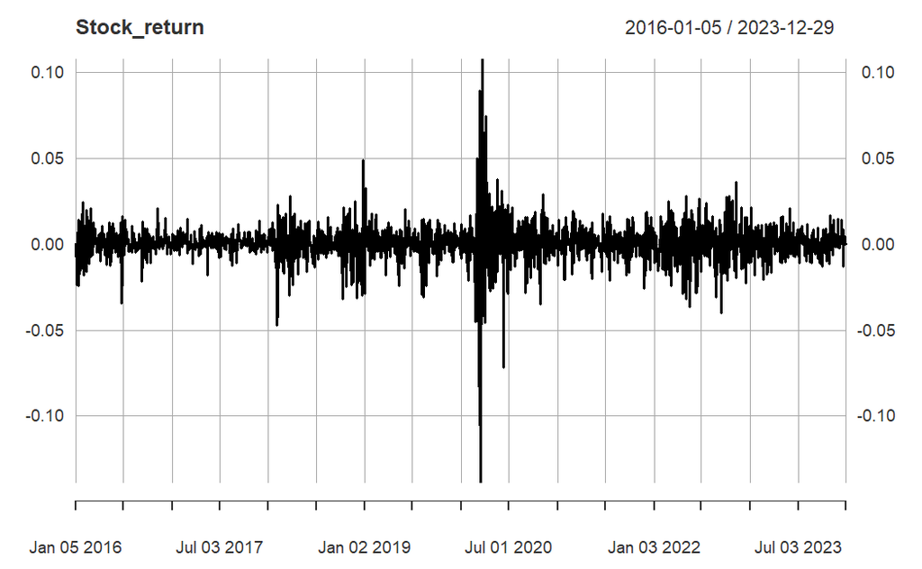

```r
View(Stock_price)

Stock_return = na.omit(diff(log(Stock_price))); plot(Stock_return) # Returns of TATA
```

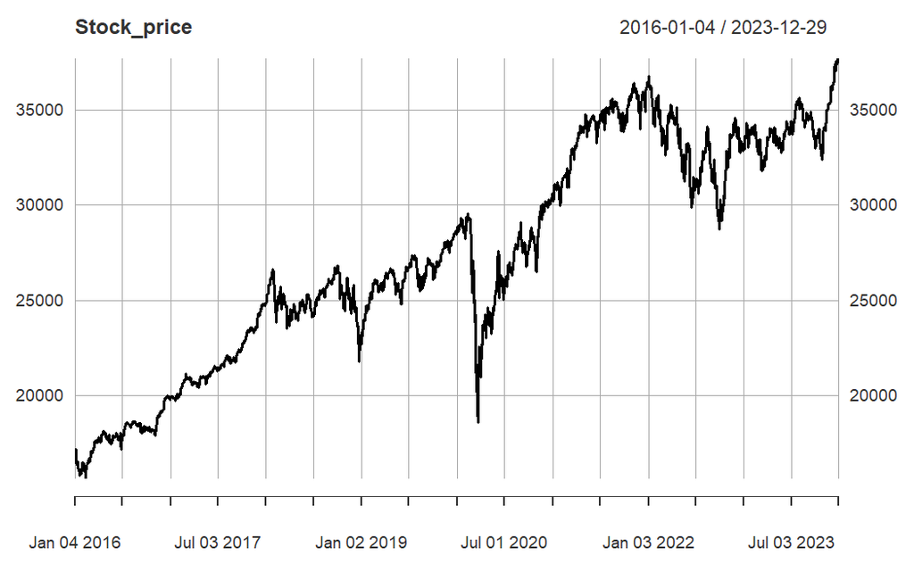

```r
plot(Stock_price)
```

**ADF Test for Stationarity**

**Objective:**

To check whether the stock return data and closing price data are stationary or not

**Analysis:**

The Augmented Dickey-Fuller Test is a statistical test used to determine whether a given time series data is stationary or not. Stationarity of time series data indicates that the mean of the series do not change over time, making it easier to model and forecast.

H0: Time Series is not stationary H1: Times Series is stationary

Whereas, p-values for return series is: 0.01 < 0.05 hence series is stationary

**Results:**

p-values for DJI returns series is: 0.01 < 0.05 hence ‘Stock_return’ series is stationary.

**Managerial Implication:**

With stationary data, modeling and forecasting stock returns become more reliable as the statistical properties of the data remain consistent over time.

```r
# Augmented Dickey-Fuller (ADF) Test for stationarity
adf_test_wn = adf.test(Stock_price); adf_test_wn # for price
```

```
    Augmented Dickey-Fuller Test

data:  Stock_price
Dickey-Fuller = -3.4437, Lag order = 12, p-value = 0.04771
alternative hypothesis: stationary
```

```r
adf_test_wn = adf.test(Stock_return); adf_test_wn # for return
```

```
    Augmented Dickey-Fuller Test

data:  Stock_return
Dickey-Fuller = -12.552, Lag order = 12, p-value = 0.01
alternative hypothesis: stationary
```

**Ljung Box test for autocorrelation**

**Objective:**

To check whether the stock return data series has autocorrelation or not

**Analysis:**

The Box-Pierce test assesses the presence of autocorrelation in a time series model. In this case, the test was applied to both returns of Dow Jones Industrial Avg data

Null Hypothesis (H0): There is no autocorrelation in the time series Alternate Hypothesis (H1): There is autocorrelation in the time series

Here p-value for return data series :3.619e-13 < 0.05, indicating series has autocorrelation

**Results:**

p-values for Dow Jones Industrial Avg data returns series is: 3.619e-13 < 0.05 hence ‘Stock_return’ series has autocorrelation.

**Managerial Implication:**

since data is auto-correlated, we can go for time-series modelling of data instead of regression

```r
#Ljung Box test for autocorrelation
lb_test_wn = Box.test(Stock_return); lb_test_wn
```

```
    Box-Pierce test

data:  Stock_return
X-squared = 52.839, df = 1, p-value = 3.619e-13
```

**ACF and PACF Plot**

**Objective:** ACF: p and PACF: q

To assess the presence of autocorrelation in a time series data set(correlation between a time series and its lagged versions). In other words, it indicates whether the past values of a series can be used to predict its future values

**Analysis:**

1. The ACF plots for the series “Stock_Return” shows the autocorrelation coefficients for different lags. The autocorrelation coefficient at lag k measures the linear dependence between the series and its lagged version by k periods. In this specific plot, the autocorrelation coefficients are plotted on the y-axis, and the lags are plotted on the x-axis.
2. The PACF plot specifically focuses on identifying the lags at which the series exhibits significant autocorrelations, net of the correlations at shorter lags.

**Results:**

**Managerial Implication:**

The presence of a significant partial autocorrelation in stock returns suggests that past values of the stock returns might have a predictive power for future returns

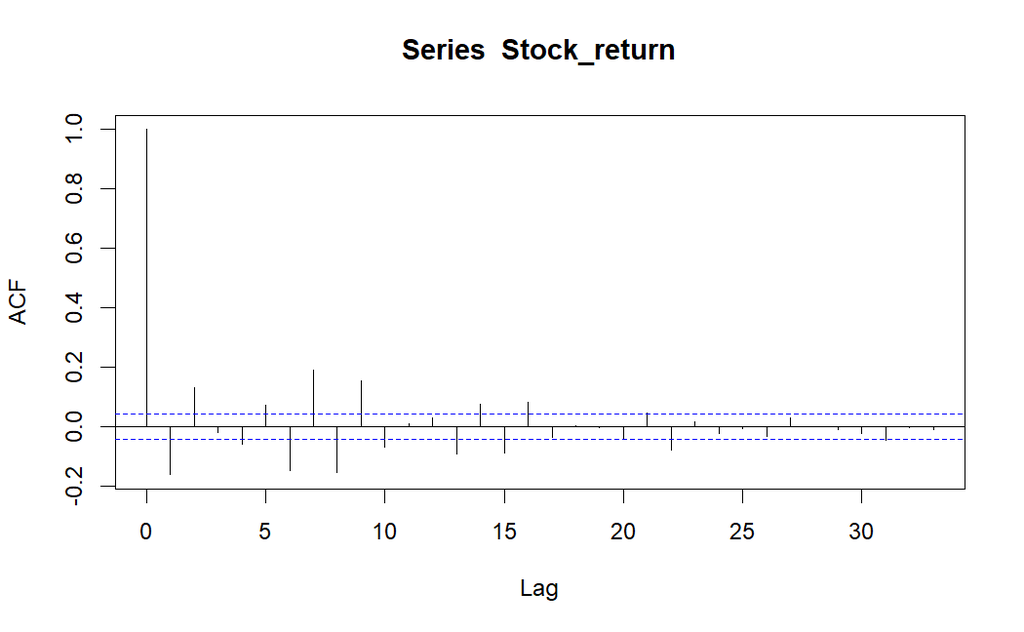

```r
#ACF and PACF plots
acf(Stock_return)
```

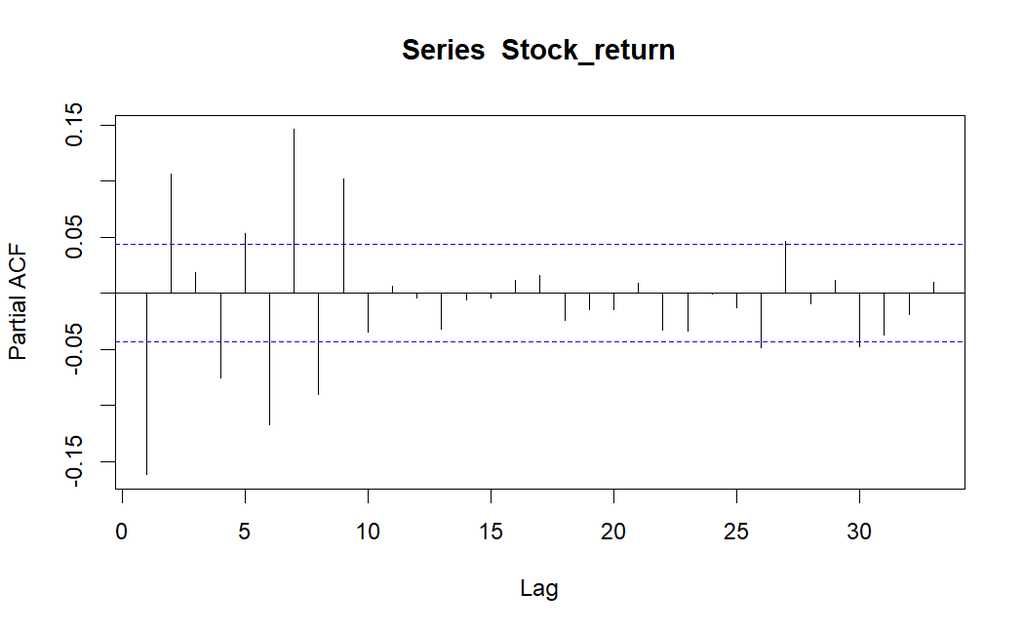

```r
pacf(Stock_return)
```

**Manual ARIMA Model**

**Objective:**

To interpret the Auto Regressive(AR) and Moving Average(MA) order values for ARMA Modelling forecast using manual ARMA

**Analysis:**

1. The ARIMA model is a time series forecasting method that combines auto-regressive (AR), differencing (I), and moving average (MA) components.
2. The method was used for different combinations of coefficients, output shows the coefficients estimated for the ARIMA(1,0,5) model has least sigma-square.

**Results:**

Out of all the orders tested for ARIMA order, order with (1,0,5) has the least variance (sigma-square):

Model Coefficients: AR (autoregressive) Coefficient (ar1): -0.8003 MA (moving average) Coefficients (ma1-ma5): 0.6925, 0.0014, 0.0919, -0.0645, 0.0457 Intercept Coefficient: 4e-04 Estimated Variance (sigma^2): 0.000126

**Managerial Implication:**

The fitted ARIMA(1,0,5) model provides valuable insights into the dynamics of the stock returns data and offers a framework for forecasting future returns.

```r
# ARIMA Model
# ARIMA (1, 0, 0) or AR(1)
ar1 = arima(Stock_return, order = c(1, 0, 0)); ar1
```

```
Call:
arima(x = Stock_return, order = c(1, 0, 0))

Coefficients:
         ar1  intercept
      -0.162      4e-04
s.e.   0.022      2e-04

sigma^2 estimated as 0.0001318:  log likelihood = 6129.57,  aic = -12253.15
```

```r
# ARIMA (2, 0, 0) or AR(2)
ar2 = arima(Stock_return, order = c(2, 0, 0)); ar2
```

```
Call:
arima(x = Stock_return, order = c(2, 0, 0))

Coefficients:
          ar1     ar2  intercept
      -0.1449  0.1059      4e-04
s.e.   0.0222  0.0222      2e-04

sigma^2 estimated as 0.0001304:  log likelihood = 6140.92,  aic = -12273.85
```

```r
# ARIMA (0, 0 , 1) or MA(1)
ma1 = arima(Stock_return, order = c(0, 0, 1)); ma1
```

```
Call:
arima(x = Stock_return, order = c(0, 0, 1))

Coefficients:
          ma1  intercept
      -0.1321      4e-04
s.e.   0.0199      2e-04

sigma^2 estimated as 0.0001325:  log likelihood = 6124.5,  aic = -12243
```

```r
# ARIMA (0, 0, 2) or MA(2)
ma2 = arima(Stock_return, order = c(0, 0, 2)); ma2
```

```
Call:
arima(x = Stock_return, order = c(0, 0, 2))

Coefficients:
          ma1     ma2  intercept
      -0.1401  0.1352      4e-04
s.e.   0.0220  0.0226      3e-04

sigma^2 estimated as 0.0001303:  log likelihood = 6141.71,  aic = -12275.43
```

```r
# ARIMA (0, 0, 3) or MA(3)
ma3 = arima(Stock_return, order = c(0, 0, 3)); ma3
```

```
Call:
arima(x = Stock_return, order = c(0, 0, 3))

Coefficients:
          ma1     ma2      ma3  intercept
      -0.1466  0.1393  -0.0385      4e-04
s.e.   0.0224  0.0226   0.0233      2e-04

sigma^2 estimated as 0.0001301:  log likelihood = 6143.05,  aic = -12276.1
```

```r
# ARIMA (0, 0, 4) or MA(4)
ma4 = arima(Stock_return, order = c(0, 0, 4)); ma4
```

```
Call:
arima(x = Stock_return, order = c(0, 0, 4))

Coefficients:
          ma1     ma2      ma3      ma4  intercept
      -0.1453  0.1321  -0.0281  -0.0288      4e-04
s.e.   0.0224  0.0231   0.0254   0.0258      2e-04

sigma^2 estimated as 0.00013:  log likelihood = 6143.69,  aic = -12275.37
```

```r
# ARIMA (1, 0, 1) or ARMA(1, 1)
arma11 = arima(Stock_return, order = c(1, 0, 1)); arma11
```

```
Call:
arima(x = Stock_return, order = c(1, 0, 1))

Coefficients:
          ar1     ma1  intercept
      -0.4615  0.2992      4e-04
s.e.   0.0663  0.0692      2e-04

sigma^2 estimated as 0.000131:  log likelihood = 6135.97,  aic = -12263.94
```

```r
# ARIMA (1, 0, 2) or ARMA(1, 2)
arma12 = arima(Stock_return, order = c(1, 0, 2)); arma12
```

```
Call:
arima(x = Stock_return, order = c(1, 0, 2))

Coefficients:
          ar1     ma1     ma2  intercept
      -0.1853  0.0407  0.1138      4e-04
s.e.   0.1304  0.1293  0.0292      2e-04

sigma^2 estimated as 0.0001301:  log likelihood = 6142.61,  aic = -12275.22
```

```r
# ARIMA (1, 0, 3) or ARMA(1, 3)
arma13 = arima(Stock_return, order = c(1, 0, 3)); arma13
```

```
Call:
arima(x = Stock_return, order = c(1, 0, 3))

Coefficients:
         ar1      ma1     ma2      ma3  intercept
      0.4374  -0.5839  0.2012  -0.0971      4e-04
s.e.  0.3090   0.3085  0.0506   0.0410      2e-04

sigma^2 estimated as 0.00013:  log likelihood = 6143.62,  aic = -12275.24
```

```r
# ARIMA (1, 0, 4) or ARMA(1, 4)
arma14 = arima(Stock_return, order = c(1, 0, 4)); arma14
```

```
Call:
arima(x = Stock_return, order = c(1, 0, 4))

Coefficients:
          ar1     ma1      ma2     ma3      ma4  intercept
      -0.8256  0.7144  -0.0058  0.0973  -0.0908      4e-04
s.e.   0.0316  0.0374   0.0267  0.0286   0.0227      2e-04

sigma^2 estimated as 0.0001262:  log likelihood = 6173.29,  aic = -12332.58
```

```r
# ARIMA (1, 0, 5) or ARMA(1, 5)
arma15 = arima(Stock_return, order = c(1, 0, 5)); arma15
```

```
Call:
arima(x = Stock_return, order = c(1, 0, 5))

Coefficients:
          ar1     ma1     ma2     ma3      ma4     ma5  intercept
      -0.8003  0.6925  0.0014  0.0919  -0.0645  0.0457      4e-04
s.e.   0.0367  0.0413  0.0274  0.0292   0.0268  0.0235      2e-04

sigma^2 estimated as 0.000126:  log likelihood = 6175.11,  aic = -12334.22
```

**Auto ARIMA Model**

**Objective:**

To interpret the Auto Regressive(AR) and Moving Average(MA) order values for ARMA Modelling forecast using Auto-ARMA method

**Analysis:**

1. The ARIMA model is a time series forecasting method that combines auto-regressive (AR), differencing (I), and moving average (MA) components.
2. The method was used to find out best order os ARIMA for further ARIMA Modelling

**Results:**

Auto-ARIMA gives order of (1,0,5) as the best order which matches with the manual ARIMA Model:

Model Coefficients: AR (autoregressive) Coefficient (ar1): -0.8003 MA (moving average) Coefficients (ma1-ma5): 0.6925, 0.0014, 0.0919, -0.0645, 0.0457 Mean: 4e-04 Variance (sigma^2): 0.0001264

**Managerial Implication:**

The fitted ARIMA(1,0,5) model provides valuable insights into the dynamics of the stock returns data and offers a framework for forecasting future returns.

```r
# Auto ARIMA
arma_pq_jj_ds = auto.arima(Stock_return); arma_pq_jj_ds # chosen order is (1,0,5)
```

```
Series: Stock_return
ARIMA(1,0,5) with non-zero mean

Coefficients:
          ar1     ma1     ma2     ma3      ma4     ma5   mean
      -0.8003  0.6925  0.0014  0.0919  -0.0645  0.0457  4e-04
s.e.   0.0367  0.0413  0.0274  0.0292   0.0268  0.0235  2e-04

sigma^2 = 0.0001264:  log likelihood = 6175.11
AIC=-12334.22   AICc=-12334.14   BIC=-12289.37
```

**Auto-Correlation test for residuals in ARIMA Modelling**

**Objective:**

To find out whether there is auto-correlation between residuals of ARIMA model and hence define validity of using ARIMA Forecast

**Analysis:**

1. The Box-Pierce test is used to assess the goodness-of-fit of a time series model by examining the autocorrelation of its residuals.
2. In this analysis, the test was applied to the residuals of an ARMA model, specifically to evaluate whether there is significant autocorrelation present.

Null Hypothesis (H0): There is no autocorrelation in the residuals of ARIMA Model Alternate Hypothesis (H1): There is autocorrelation in the residuals of ARIMA Model

Here p-value for ARIMA Model residuals is :0.874 > 0.05, indicating residuals have no auto-correlation

**Results:**

The obtained p-value of 0.874 is substantially greater than the conventional significance level of 0.05. Therefore, there we do not reject the null hypothesis and there is no autocorrelation in the residuals.

**Managerial Implication:**

The Box-Pierce test results provide reassurance regarding the adequacy of the ARMA model in forecasting the data, hence we can forecast the data with ARIMA Modelling

```r
# Autocorrelation test for residuals
lb_test_arma_pq_jj_ds = Box.test(arma_pq_jj_ds$residuals); lb_test_arma_pq_jj_ds #no-autocorrelation (do not reject null) good ARIMA Model, now forecast
```

```
    Box-Pierce test

data:  arma_pq_jj_ds$residuals
X-squared = 0.025153, df = 1, p-value = 0.874
```

**Forecasting with ARIMA Modelling**

**Objective:**

To forecast the stock data returns using ARIMA Modelling

**Analysis:**

Since there is no auto-correlation between residuals of ARIMA(1,0,5), we forecasted the stock values for next 500 time units.

**Results:**

ARIMA modelling forecasted the stock values for next 500 time units.

**Managerial Implication:**

Now that we have forecasted the stock values using ARIMA modelling we test its validity.

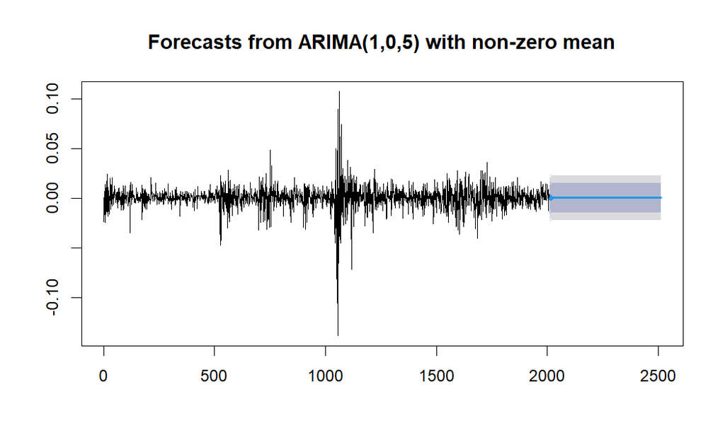

```r
#ARIMA Modelling
jj_ds_fpq = forecast(arma_pq_jj_ds, h = 500)
plot(jj_ds_fpq)
```

**Auto-Correlation test for residual square**

**Objective:**

To predict the model’s volatility based on auto-correlation between residual-square(variance) of ARIMA model

**Analysis:**

1. The Box-Pierce test is used to assess the goodness-of-fit of a time series model by examining the autocorrelation of its residuals-square.
2. In this analysis, the test was applied to the residuals-square of an ARIMA model, specifically to evaluate whether there is significant autocorrelation present or not.

Null Hypothesis (H0): There is no autocorrelation in the residuals-square of ARIMA Model Alternate Hypothesis (H1): There is autocorrelation in the residuals-square of ARIMA Model

**Results:**

The obtained p-value of 2.2e-16 is substantially less than the conventional significance level of 0.05. Therefore, we reject the null hypothesis and there is autocorrelation in the residuals.

**Managerial Implication:**

The Box-Pierce test results provide information that there is significant autocorrelation amongst residual-square and hence significant volatility.

```r
# Autocorrelation test for residual square(to check autocorrelation in residual square)
lb_test_arma_pq_jj_ds = Box.test(jj_ds_fpq$residuals^2); lb_test_arma_pq_jj_ds #there is autocorrelation
```

```
    Box-Pierce test

data:  jj_ds_fpq$residuals^2
X-squared = 296.31, df = 1, p-value < 2.2e-16
```

**ARCH-LM test for heteroskedasticity**

**Objective:**

To predict the model’s volatility based on ARCH-LM test for heteroskedasticity in residual-square of ARIMA model

**Analysis:**

1. The ARCH (Autoregressive Conditional Heteroscedasticity) LM-test is used to assess whether there are ARCH effects present in the residuals of a time series model.
2. ARCH effects refer to the presence of conditional heteroscedasticity, where the variance of the residuals depends on past values of the series.

Null Hypothesis (H0): There is no ARCH effects(Homoskedastic) Alternate Hypothesis (H1): There is ARCH effects present in residual-square(variance) (Heteroskedastic)

Here p-value for ARIMA Model residuals-square is : 2.2e-16 < 0.05, indicating heteroskedasticity in residual-square

**Results:**

The obtained p-value of 2.2e-16 is substantially less than the conventional significance level of 0.05. Therefore, we reject the null hypothesis and there is heteroskedasticity in residual-square.

**Managerial Implication:**

The significant ARCH effects detected in the squared residuals indicate that the current time series model fails to account for conditional heteroscedasticity adequately.

```r
#Test for Volatility Clustering or Heteroskedasticity: Box Test

nse_ret_arch_test = ArchTest(jj_ds_fpq$residuals^2, lags = 20) # H0: No ARCH Effects, hence homoskedastic, go for GARCH
nse_ret_arch_test #here there is ARCH effect hence residual square is heteroskedastic
```

```
    ARCH LM-test; Null hypothesis: no ARCH effects

data:  jj_ds_fpq$residuals^2
Chi-squared = 690.14, df = 20, p-value < 2.2e-16
```

**GARCH Modelling for ARIMA model**

**Objective:**

To model ARIMA data with GARCH and test the fit of GARCH model with data

**Analysis:**

The GARCH tests the fit of the GARCH model to the data. These statistics and tests evaluate the adequacy of the model in capturing the volatility dynamics of the time series.

**Results:**

Joint Statistic: The joint statistic is 89.5651, indicating the overall goodness-of-fit of the GARCH model. Individual Statistics: mu (Mean): 0.2169 omega (Constant Term in Volatility Equation): 25.7892 alpha1 (Coefficient of Lagged Squared Errors): 4.2219 beta1 (Coefficient of Lagged Conditional Variance): 2.4185 Asymptotic Critical Values (10%, 5%, 1%): For Joint Statistic: 1.07, 1.24, 1.6 For Individual Statistics: 0.35, 0.47, 0.75

**Managerial Implication:**

GARCH model provides insights into the volatility dynamics of the time series, the results of the goodness-of-fit test suggest that the model may have limitations in accurately capturing the underlying patterns.

```r
#GARCH Model

garch_model1 = ugarchspec(variance.model = list(model = 'sGARCH', garchOrder = c(1,1)), mean.model = list(armaOrder = c(0,0), include.mean = TRUE)) # since we are modelling mean
nse_ret_garch1 = ugarchfit(garch_model1, data = jj_ds_fpq$residuals^2);
nse_ret_garch1
```

```
*---------------------------------*
*          GARCH Model Fit        *
*---------------------------------*

Conditional Variance Dynamics
-----------------------------------
GARCH Model : sGARCH(1,1)
Mean Model  : ARFIMA(0,0,0)
Distribution    : norm

Optimal Parameters
------------------------------------
        Estimate  Std. Error    t value Pr(>|t|)
mu      0.000052    0.000003  15.520871  0.00000
omega   0.000000    0.000000   0.001566  0.99875
alpha1  0.050001    0.002300  21.742752  0.00000
beta1   0.900001    0.004111 218.900754  0.00000

Robust Standard Errors:
        Estimate  Std. Error  t value Pr(>|t|)
mu      0.000052    0.065223 0.000793  0.99937
omega   0.000000    0.007585 0.000000  1.00000
alpha1  0.050001    3.542805 0.014113  0.98874
beta1   0.900001   81.214341 0.011082  0.99116

LogLikelihood : 14255.37

Information Criteria
------------------------------------

Akaike       -14.173
Bayes        -14.162
Shibata      -14.173
Hannan-Quinn -14.169

Weighted Ljung-Box Test on Standardized Residuals
------------------------------------
                        statistic   p-value
Lag[1]                      46.15 1.098e-11
Lag[2*(p+q)+(p+q)-1][2]     60.66 1.110e-16
```

[output cut: 19 more lines]

```
Nyblom stability test
------------------------------------
Joint Statistic:  89.5651
Individual Statistics:
mu      0.2169
omega  25.7892
alpha1  4.2219
beta1   2.4185

Asymptotic Critical Values (10% 5% 1%)
Joint Statistic:         1.07 1.24 1.6
Individual Statistic:    0.35 0.47 0.75

Sign Bias Test
------------------------------------
```

|  | t-value | prob | sig |
| --- | --- | --- | --- |
| Sign Bias | 1.03037059 | 0.3029603 |  |
| Negative Sign Bias | 0.09182206 | 0.9268486 |  |
| Positive Sign Bias | 0.10425235 | 0.9169795 |  |
| Joint Effect | 4.92694587 | 0.1772254 |  |

```
Adjusted Pearson Goodness-of-Fit Test:
------------------------------------
  group statistic p-value(g-1)
1    20      1482   2.962e-303
2    30      1583   1.107e-315
3    40      1654   2.866e-322
4    50      1694   9.387e-323


Elapsed time : 0.1292989
```

**ARCH-LM test for heteroskedasticity of GARCH Modelling**

**Objective:**

To predict the GARCH model’s volatility based on ARCH-LM test for heteroskedasticity in residual of GARCH model

**Analysis:**

1. The ARCH (Autoregressive Conditional Heteroscedasticity) LM-test is used to assess whether there are ARCH effects present in the residuals of a time series model.
2. ARCH effects refer to the presence of conditional heteroscedasticity, where the variance of the residuals depends on past values of the series.

Null Hypothesis (H0): There is no ARCH effects(Homoskedastic) Alternate Hypothesis (H1): There is ARCH effects present in residual-square(variance) (Heteroskedastic)

Here p-value for ARIMA Model residuals-square is : 2.2e-16 < 0.05, indicating heteroskedasticity in residual

**Results:**

The obtained p-value of 2.2e-16 is substantially less than the conventional significance level of 0.05. Therefore, we reject the null hypothesis and there is heteroskedasticity in residual of GARCH Model indicating the inadquacy of GARCH Model.

**Managerial Implication:**

The significant ARCH effects detected in the residuals indicate that the current GARCH model fails to account for conditional heteroscedasticity adequately.

```r
#Heteroskedasticity test
# Test for Volatility Clustering or Heteroskedasticity: ARCH Test
gar_resd = residuals(nse_ret_garch1)
stk_ret_arch_test1 = ArchTest(gar_resd, lags = 1) # H0: No ARCH Effects
stk_ret_arch_test1 # Inference : Return Series is Heteroskedastic (Has Volatility Clustering
```

```
    ARCH LM-test; Null hypothesis: no ARCH effects

data:  gar_resd
Chi-squared = 71.714, df = 1, p-value < 2.2e-16
```

**GARCH Modelling**

**Objective:**

To test the fit of GARCH Model on stock return data

**Analysis:**

The GARCH tests the fit of the GARCH model to the data. These statistics and tests evaluate the adequacy of the model in capturing the volatility dynamics of the time series.

**Managerial Implication:**

Model Adequacy: The GARCH model with specified parameters captures the volatility dynamics and mean behavior to some extent.

Model Evaluation: Diagnostic tests indicate no significant issues such as serial correlation or ARCH effects in the residuals. However, goodness-of-fit tests reveal discrepancies between the model and the data.

Forecast Reliability: Caution should be exercised when using forecasts from the GARCH model, considering potential limitations in the model fit.

Risk Management: Inaccurate volatility modeling can impact risk management decisions. Further evaluation and refinement of the GARCH model or consideration of alternative models may be necessary for robust risk assessment.

GARCH model provides insights into volatility dynamics, discrepancies in goodness-of-fit tests suggest potential limitations.

```r
garch_modelf = ugarchspec(variance.model = list(model = 'sGARCH', garchOrder = c(1,1)), mean.model = list(armaOrder = c(1,5), include.mean = TRUE))
stk_ret_garch = ugarchfit(garch_modelf, data = Stock_return);stk_ret_garch
```

```
*---------------------------------*
*          GARCH Model Fit        *
*---------------------------------*

Conditional Variance Dynamics
-----------------------------------
GARCH Model : sGARCH(1,1)
Mean Model  : ARFIMA(1,0,5)
Distribution    : norm

Optimal Parameters
------------------------------------
        Estimate  Std. Error     t value Pr(>|t|)
mu      0.000789    0.000142    5.559010 0.000000
ar1    -0.949354    0.006512 -145.786280 0.000000
ma1     0.923449    0.000131 7035.192293 0.000000
ma2     0.006963    0.024018    0.289888 0.771902
ma3    -0.008884    0.033759   -0.263152 0.792433
ma4    -0.053214    0.031595   -1.684245 0.092134
ma5     0.000781    0.023431    0.033315 0.973423
omega   0.000004    0.000007    0.536945 0.591306
alpha1  0.184668    0.015257   12.103512 0.000000
beta1   0.786456    0.078610   10.004554 0.000000

Robust Standard Errors:
        Estimate  Std. Error    t value Pr(>|t|)
mu      0.000789    0.001089   0.724373  0.46884
ar1    -0.949354    0.080140 -11.846128  0.00000
ma1     0.923449    0.001268 728.145325  0.00000
ma2     0.006963    0.101439   0.068639  0.94528
ma3    -0.008884    0.083802  -0.106010  0.91558
ma4    -0.053214    0.064103  -0.830132  0.40646
ma5     0.000781    0.042711   0.018277  0.98542
omega   0.000004    0.000130   0.027091  0.97839
alpha1  0.184668    0.269514   0.685189  0.49322
beta1   0.786456    1.595821   0.492822  0.62214

LogLikelihood : 6745.4

Information Criteria
```

[output cut: 37 more lines]

```
ma1    0.11420
ma2    0.09358
ma3    0.08253
ma4    0.12556
ma5    0.16428
omega  0.08299
alpha1 0.34757
beta1  0.56013

Asymptotic Critical Values (10% 5% 1%)
Joint Statistic:         2.29 2.54 3.05
Individual Statistic:    0.35 0.47 0.75

Sign Bias Test
------------------------------------
```

|  | t-value | prob | sig |
| --- | --- | --- | --- |
| Sign Bias | 1.7594225 | 0.07865819 | * |
| Negative Sign Bias | 0.3158137 | 0.75217679 |  |
| Positive Sign Bias | 0.7510138 | 0.45273245 |  |
| Joint Effect | 9.0512333 | 0.02861741 | ** |

```
Adjusted Pearson Goodness-of-Fit Test:
------------------------------------
  group statistic p-value(g-1)
1    20     64.28    8.002e-07
2    30     83.85    3.118e-07
3    40    104.94    5.891e-08
4    50    103.50    8.995e-06


Elapsed time : 0.766593
```

**GARCH Modelling**

**Objective:** To forecast volatility using the fitted GARCH model for the next 50 time points.

**Analysis:** Used the ‘ugarchforecast’ function to generate volatility forecasts for the next 50 time points.

**Results:**

**GARCH Model Forecast:** Model: sGARCH - Horizon: 50 - Roll Steps: 0 - Out of Sample: 0

**Implication:** The forecasted values represent the predicted volatility for the next 50 time points based on the fitted GARCH model. These forecasts can be useful for risk management and decision-making, providing insights into the expected future volatility of the financial time series.

```r
# GARCH Forecast
stk_ret_garch_forecast1 = ugarchforecast(stk_ret_garch, n.ahead = 50); stk_ret_garch_forecast1
```

```
*------------------------------------*
*       GARCH Model Forecast         *
*------------------------------------*
Model: sGARCH
Horizon: 50
Roll Steps: 0
Out of Sample: 0

0-roll forecast [T0=2023-12-29]:
        Series    Sigma
T+1  0.0002430 0.005849
T+2  0.0011740 0.006061
T+3  0.0003815 0.006260
T+4  0.0012712 0.006447
T+5  0.0003294 0.006624
T+6  0.0012249 0.006791
T+7  0.0003748 0.006950
T+8  0.0011818 0.007101
T+9  0.0004156 0.007244
T+10 0.0011430 0.007380
T+11 0.0004525 0.007510
T+12 0.0011081 0.007635
T+13 0.0004857 0.007753
T+14 0.0010765 0.007867
T+15 0.0005156 0.007976
T+16 0.0010481 0.008080
T+17 0.0005426 0.008180
T+18 0.0010225 0.008276
T+19 0.0005669 0.008368
T+20 0.0009995 0.008457
T+21 0.0005888 0.008542
T+22 0.0009787 0.008623
T+23 0.0006085 0.008702
T+24 0.0009599 0.008778
T+25 0.0006263 0.008851
T+26 0.0009430 0.008921
T+27 0.0006424 0.008989
T+28 0.0009278 0.009054
T+29 0.0006568 0.009117
T+30 0.0009141 0.009178
T+31 0.0006699 0.009236
T+32 0.0009017 0.009293
T+33 0.0006816 0.009347
T+34 0.0008905 0.009400
T+35 0.0006922 0.009451
T+36 0.0008805 0.009500
T+37 0.0007017 0.009548
T+38 0.0008714 0.009594
T+39 0.0007103 0.009638
T+40 0.0008633 0.009681
T+41 0.0007181 0.009722
T+42 0.0008559 0.009762
T+43 0.0007250 0.009801
T+44 0.0008493 0.009839
T+45 0.0007313 0.009875
T+46 0.0008433 0.009910
T+47 0.0007370 0.009944
T+48 0.0008379 0.009977
T+49 0.0007421 0.010009
T+50 0.0008331 0.010040
```

```r
plot(stk_ret_garch_forecast1)
```

```
Make a plot selection (or 0 to exit):

1:   Time Series Prediction (unconditional)
2:   Time Series Prediction (rolling)
3:   Sigma Prediction (unconditional)
4:   Sigma Prediction (rolling)
```

```r
1
```

```
Make a plot selection (or 0 to exit):

1:   Time Series Prediction (unconditional)
2:   Time Series Prediction (rolling)
3:   Sigma Prediction (unconditional)
4:   Sigma Prediction (rolling)
```

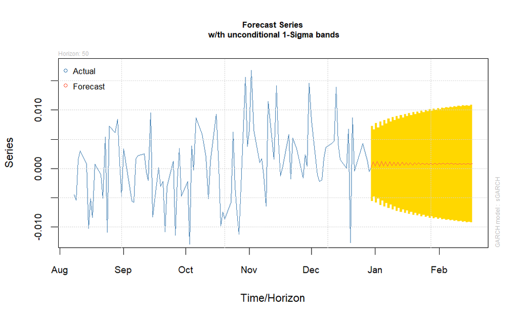

```
Make a plot selection (or 0 to exit):

1:   Time Series Prediction (unconditional)
2:   Time Series Prediction (rolling)
3:   Sigma Prediction (unconditional)
4:   Sigma Prediction (rolling)
```

```r
3
```

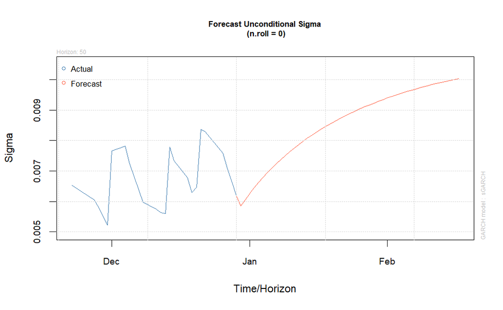

```r
0
```